# Exploratory Data Analysis on Titanic Surivival

2019-11-07

# 1 Preparations

## 1.1 Load libraries

```r
library(tidyverse)
library(scales)
# set your own working directory
setwd("C:/Users/Hao/Dropbox/newtermphd/Term12/Rworkshop_tidyverse_2019/exercise/Titanic/")
```

## 1.2 Read data

```r
titanic <- read_csv("titanic.csv")
#library(readxl)
#titanic <- read_excel("titanic.xlsx") #if you have an excel file
```

# 2 Glance at data

## 2.1 Data structure

```
## # A tibble: 891 x 12
##    PassengerId Survived Pclass Name  Sex     Age SibSp Parch Ticket  Fare
##          <int>    <int>  <int> <chr> <chr> <dbl> <int> <int> <chr>  <dbl>
##  1           1        0      3 Brau~ male     22     1     0 A/5 2~  7.25
##  2           2        1      1 Cumi~ fema~    38     1     0 PC 17~ 71.3
##  3           3        1      3 Heik~ fema~    26     0     0 STON/~  7.92
##  4           4        1      1 Futr~ fema~    35     1     0 113803 53.1
##  5           5        0      3 Alle~ male     35     0     0 373450  8.05
##  6           6        0      3 Mora~ male     NA     0     0 330877  8.46
##  7           7        0      1 McCa~ male     54     0     0 17463  51.9
##  8           8        0      3 Pals~ male      2     3     1 349909 21.1
##  9           9        1      3 John~ fema~    27     0     2 347742 11.1
## 10          10        1      2 Nass~ fema~    14     1     0 237736 30.1
## # ... with 881 more rows, and 2 more variables: Cabin <chr>,
## #   Embarked <chr>
```

```
## Observations: 891
## Variables: 12
## $ PassengerId <int> 1, 2, 3, 4, 5, 6, 7, 8, 9, 10, 11, 12, 13, 14, 15,...
## $ Survived    <int> 0, 1, 1, 1, 0, 0, 0, 0, 1, 1, 1, 1, 0, 0, 0, 1, 0,...
## $ Pclass      <int> 3, 1, 3, 1, 3, 3, 1, 3, 3, 2, 3, 1, 3, 3, 3, 2, 3,...
## $ Name        <chr> "Braund, Mr. Owen Harris", "Cumings, Mrs. John Bra...
## $ Sex         <chr> "male", "female", "female", "female", "male", "mal...
## $ Age         <dbl> 22, 38, 26, 35, 35, NA, 54, 2, 27, 14, 4, 58, 20, ...
## $ SibSp       <int> 1, 1, 0, 1, 0, 0, 0, 3, 0, 1, 1, 0, 0, 1, 0, 0, 4,...
## $ Parch       <int> 0, 0, 0, 0, 0, 0, 0, 1, 2, 0, 1, 0, 0, 5, 0, 0, 1,...
## $ Ticket      <chr> "A/5 21171", "PC 17599", "STON/O2. 3101282", "1138...
## $ Fare        <dbl> 7.2500, 71.2833, 7.9250, 53.1000, 8.0500, 8.4583, ...
## $ Cabin       <chr> NA, "C85", NA, "C123", NA, NA, "E46", NA, NA, NA, ...
## $ Embarked    <chr> "S", "C", "S", "S", "S", "Q", "S", "S", "S", "C", ...
```

## 2.2 Number of distinct values for each variable

Make use of `n_distinct`

```r
# Count by summarize_all
titanic %>%
  summarize_all(n_distinct) %>%
  gather(key = "variable",value="Unique")
```

```
## # A tibble: 12 x 2
##    variable    Unique
##    <chr>        <int>
##  1 PassengerId    891
##  2 Survived         2
##  3 Pclass           3
##  4 Name           891
##  5 Sex              2
##  6 Age             89
##  7 SibSp            7
##  8 Parch            7
##  9 Ticket         681
## 10 Fare           248
## 11 Cabin          148
## 12 Embarked         4
```

## 2.3 Missing rate for each variable

```r
# Count by summarize_all
titanic %>%
  summarize_all((~sum(is.na(.))/n())) %>%
  gather(key = "variable",value="missingRate")
```

```
## # A tibble: 12 x 2
##    variable    missingRate
##    <chr>             <dbl>
##  1 PassengerId     0
##  2 Survived        0
##  3 Pclass          0
##  4 Name            0
##  5 Sex             0
##  6 Age             0.199
##  7 SibSp           0
##  8 Parch           0
##  9 Ticket          0
## 10 Fare            0
## 11 Cabin           0.771
## 12 Embarked        0.00224
```

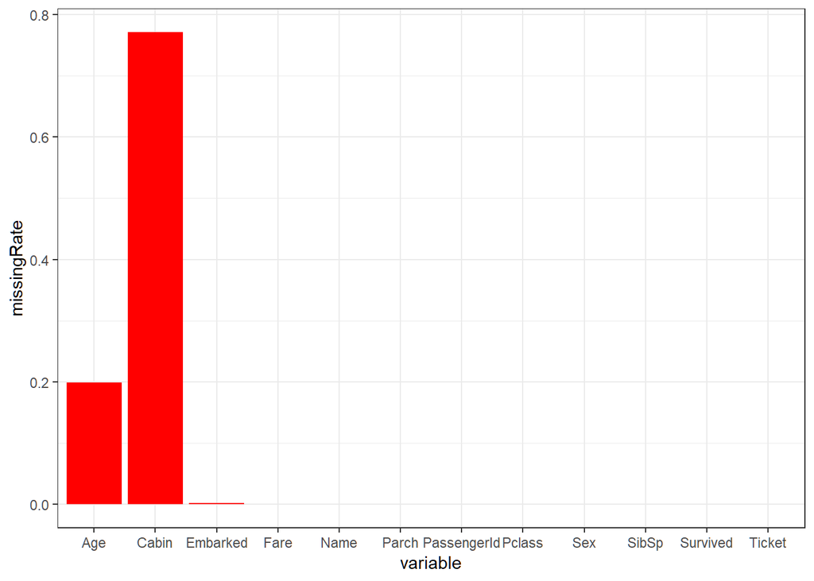

```r
# Create a bar chart to display it
titanic %>%
  summarize_all((~sum(is.na(.))/n())) %>%
  gather(key = "variable",value="missingRate") %>%
  ggplot(aes(variable,missingRate))+
  geom_bar(stat="identity",fill="red")+
  theme_bw()
```

## 2.4 Create a variable SurvivedLabel as a factor of Survival

```r
titanic
```

```
## # A tibble: 891 x 12
##    PassengerId Survived Pclass Name  Sex     Age SibSp Parch Ticket  Fare
##          <int>    <int>  <int> <chr> <chr> <dbl> <int> <int> <chr>  <dbl>
##  1           1        0      3 Brau~ male     22     1     0 A/5 2~  7.25
##  2           2        1      1 Cumi~ fema~    38     1     0 PC 17~ 71.3
##  3           3        1      3 Heik~ fema~    26     0     0 STON/~  7.92
##  4           4        1      1 Futr~ fema~    35     1     0 113803 53.1
##  5           5        0      3 Alle~ male     35     0     0 373450  8.05
##  6           6        0      3 Mora~ male     NA     0     0 330877  8.46
##  7           7        0      1 McCa~ male     54     0     0 17463  51.9
##  8           8        0      3 Pals~ male      2     3     1 349909 21.1
##  9           9        1      3 John~ fema~    27     0     2 347742 11.1
## 10          10        1      2 Nass~ fema~    14     1     0 237736 30.1
## # ... with 881 more rows, and 2 more variables: Cabin <chr>,
## #   Embarked <chr>
```

```r
# Create a variable SurvivedLabel as a factor of Survival
titanic <- titanic %>%
  mutate(SurvivedLabel=factor(Survived))
```

# 3 Survival for each variable

## 3.1 Overall

Count the number and proportion of survived passengers.

```r
# Step 1: group_by SurvivedLabel
# Step 2: summarise count using count=n()
# Step 3: mutate to find the proportion, count/sum(count)
titanic %>%
  group_by(SurvivedLabel) %>%
  summarise(count=n()) %>%
  mutate(prop=count/sum(count))
```

```
## # A tibble: 2 x 3
##   SurvivedLabel count  prop
##   <fct>         <int> <dbl>
## 1 0               549 0.616
## 2 1               342 0.384
```

## 3.2 Pclass

Ticket class.

```r
# Use summarise and n() to count each Pclass
# as well as mean() to compute the survival rate
# Step 1: group_by
# Step 2: summarise
titanic %>%
  group_by(Pclass) %>%
  summarise(sur=mean(Survived),
            count=n())
```

```
## # A tibble: 3 x 3
##   Pclass   sur count
##    <int> <dbl> <int>
## 1      1 0.630   216
## 2      2 0.473   184
## 3      3 0.242   491
```

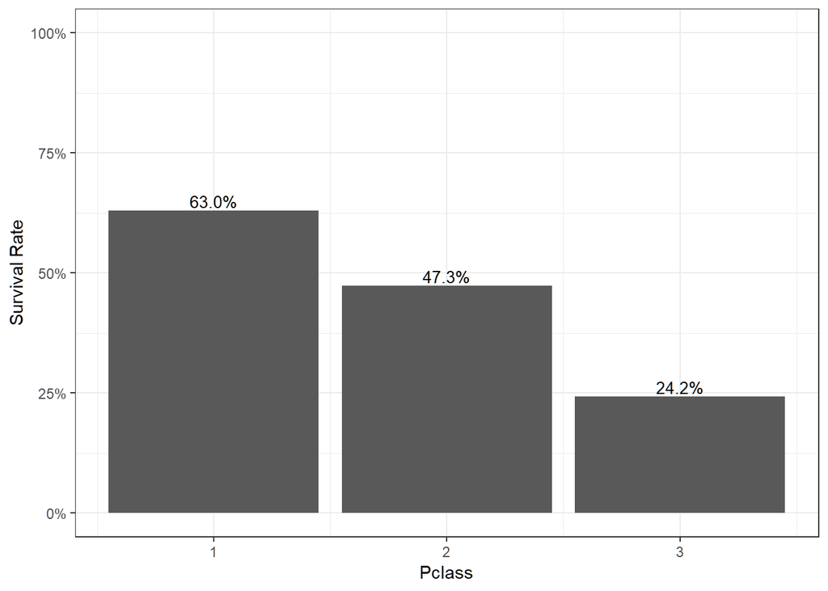

```r
# Bar chart for the surival rate
titanic %>%
  group_by(Pclass) %>%
  summarise(sur=mean(Survived)) %>%
  ggplot(aes(Pclass,sur)) +
  geom_bar(stat="identity")+
  geom_text(aes(label=scales::percent(sur,
                                      accuracy=0.1,
                                      suffix="%") ),
            size=3.5,vjust=-0.25,
            position = position_dodge(width = 0.9))+
  scale_y_continuous(labels = scales::percent, limits = c(0,1))+
  labs(y="Survival Rate")+
  theme_bw()
```

## 3.3 Sex

```r
# Use summarise and n() to count each Sex
# as well as mean() to compute the survival rate
# Step 1: group_by
# Step 2: summarise
titanic %>%
  group_by(Sex) %>%
  summarise(sur=mean(Survived),
            count=n())
```

```
## # A tibble: 2 x 3
##   Sex      sur count
##   <chr>  <dbl> <int>
## 1 female 0.742   314
## 2 male   0.189   577
```

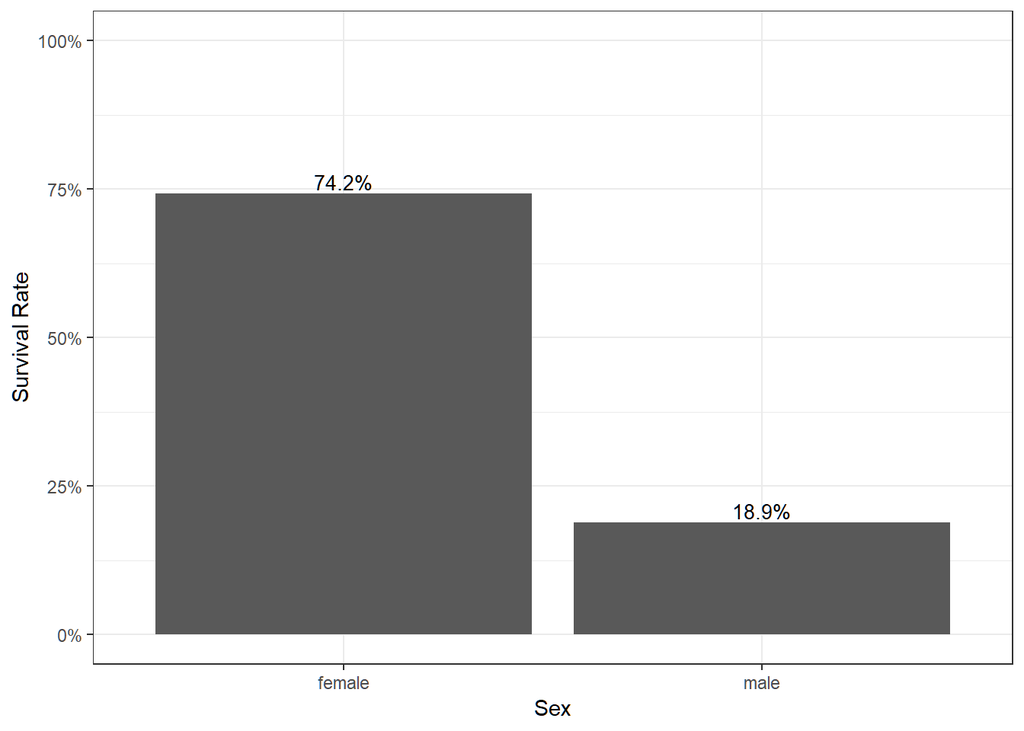

```r
# Bar chart for the surival rate
titanic %>%
  group_by(Sex) %>%
  summarise(sur=mean(Survived)) %>%
  ggplot(aes(Sex,sur)) +
  geom_bar(stat="identity")+
  geom_text(aes(label=scales::percent(sur,
                                      accuracy=0.1,
                                      suffix="%") ),
            size=3.5,vjust=-0.25,
            position = position_dodge(width = 0.9))+
  scale_y_continuous(labels = scales::percent, limits = c(0,1))+
  labs(y="Survival Rate")+
  theme_bw()
```

## 3.4 Age

Use `SurvivedLabel` as a group indicator in boxplot. Notice that there are many missing values.

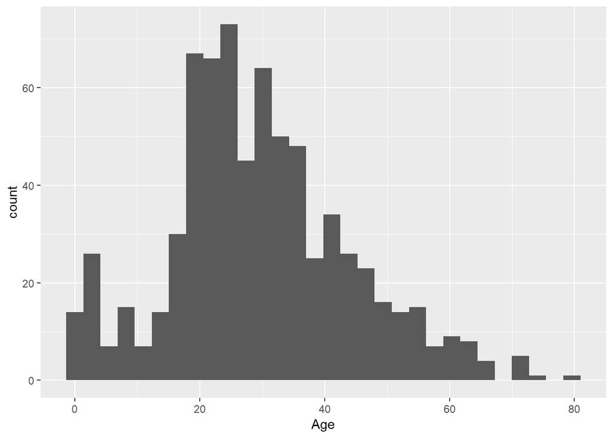

```r
# Create a histogram of Age
titanic %>%
  ggplot(aes(x=Age))+
  geom_histogram()
```

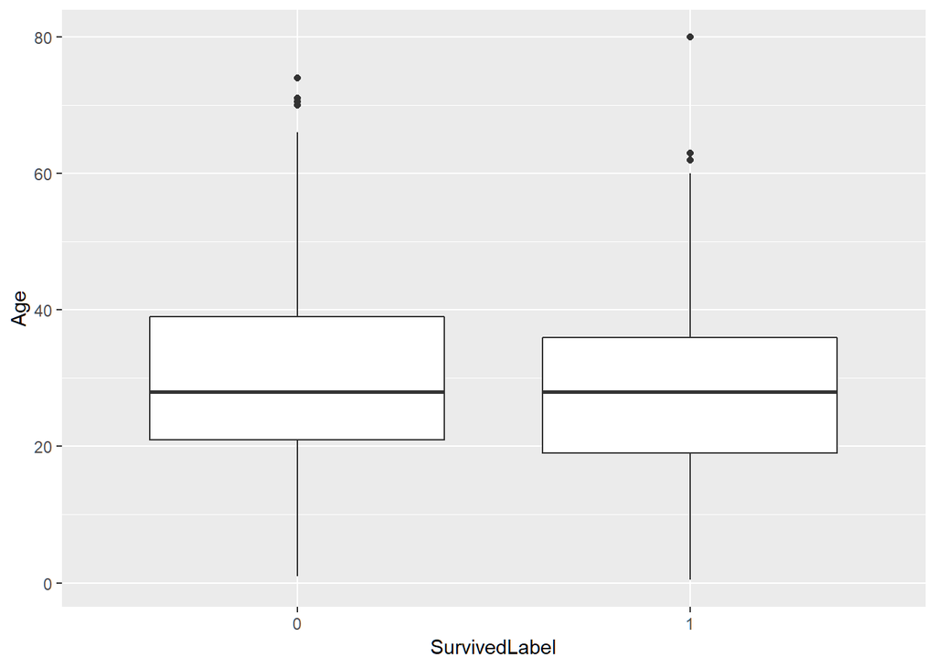

```r
# Boxplot between SurvivedLabel and Age
titanic %>%
  ggplot(aes(SurvivedLabel,Age)) +
  geom_boxplot()
```

## 3.5 SibSp

Number of siblings / spouses aboard the Titanic. The survival rate within each group indicate that the survival rate drops for people with higher SibSp except for people who had no siblings.

```r
# Use summarise and n() to count each SibSp
# as well as mean() to compute the survival rate
# Step 1: group_by
# Step 2: summarise
titanic %>%
  group_by(SibSp) %>%
  summarise(sur=mean(Survived),
            count=n())
```

```
## # A tibble: 7 x 3
##   SibSp   sur count
##   <int> <dbl> <int>
## 1     0 0.345   608
## 2     1 0.536   209
## 3     2 0.464    28
## 4     3 0.25     16
## 5     4 0.167    18
## 6     5 0         5
## 7     8 0         7
```

## 3.6 Parch

Number of parents / children aboard the Titanic.

```r
# Use summarise and n() to count each Parch
# as well as mean() to compute the survival rate
# Step 1: group_by
# Step 2: summarise
titanic %>%
  group_by(Parch) %>%
  summarise(sur=mean(Survived),
            count=n())
```

```
## # A tibble: 7 x 3
##   Parch   sur count
##   <int> <dbl> <int>
## 1     0 0.344   678
## 2     1 0.551   118
## 3     2 0.5      80
## 4     3 0.6       5
## 5     4 0         4
## 6     5 0.2       5
## 7     6 0         1
```

## 3.7 Fare

Passenger fare.

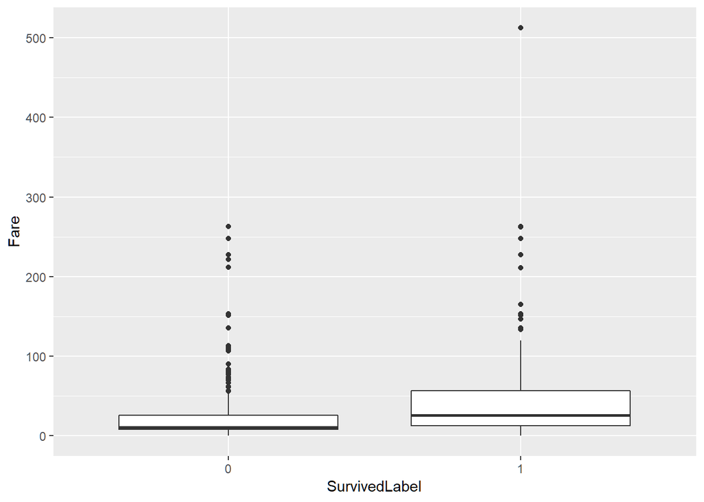

```r
# Boxplot between SurvivedLabel and Fare
titanic %>%
  ggplot(aes(SurvivedLabel,Fare)) +
  geom_boxplot()
```

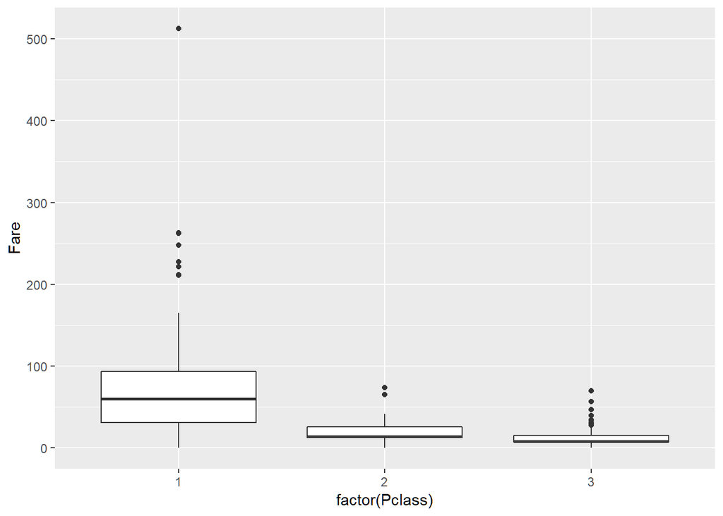

```r
# Boxplot between factor(Pclass) and Fare
titanic %>%
  ggplot(aes(factor(Pclass),Fare)) +
  geom_boxplot()
```

## 3.8 Embarked

Port of Embarkation.

```r
# Use summarise and n() to count each Embarked
# as well as mean() to compute the survival rate
# Step 1: group_by
# Step 2: summarise
titanic %>%
  group_by(Embarked) %>%
  summarise(sur=mean(Survived),
            count=n())
```

```
## # A tibble: 4 x 3
##   Embarked   sur count
##   <chr>    <dbl> <int>
## 1 C        0.554   168
## 2 Q        0.390    77
## 3 S        0.337   644
## 4 <NA>     1         2
```

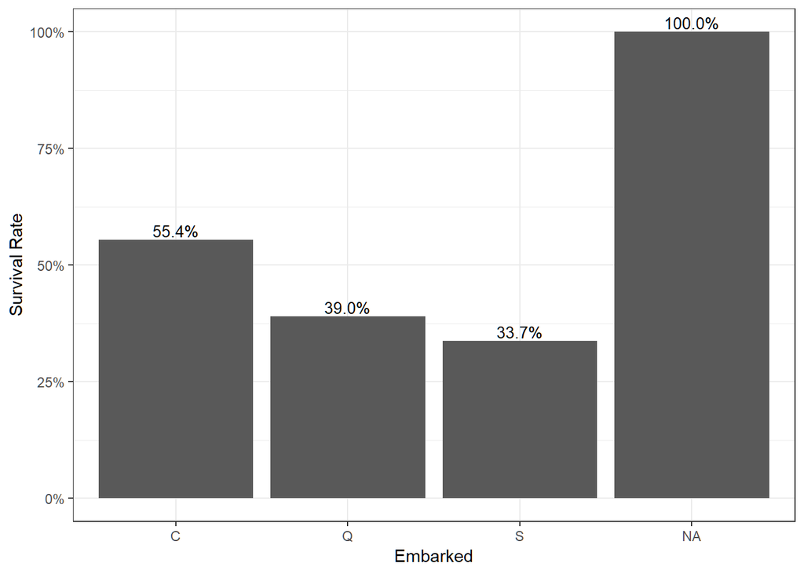

```r
# Bar chart for the surival rate
titanic %>%
  group_by(Embarked) %>%
  summarise(sur=mean(Survived)) %>%
  ggplot(aes(Embarked,sur)) +
  geom_bar(stat="identity")+
  geom_text(aes(label=scales::percent(sur,
                                      accuracy=0.1,
                                      suffix="%") ),
            size=3.5,vjust=-0.25,
            position = position_dodge(width = 0.9))+
  scale_y_continuous(labels = scales::percent, limits = c(0,1))+
  labs(y="Survival Rate")+
  theme_bw()
```

## 3.9 Sex and Pclass

```r
# Survival rates and counts for the combinations of Sex and Pclass
# Use mutate(SexPclass=paste0(Sex,"_",Pclass))
# to create an interaction variable
titanic %>%
  group_by(Sex,Pclass) %>%
  summarise(sur=mean(Survived),
            count=n()) %>%
  ungroup() %>%
  mutate(SexPclass=paste0(Sex,"_",Pclass))
```

```
## # A tibble: 6 x 5
##   Sex    Pclass   sur count SexPclass
##   <chr>   <int> <dbl> <int> <chr>
## 1 female      1 0.968    94 female_1
## 2 female      2 0.921    76 female_2
## 3 female      3 0.5     144 female_3
## 4 male        1 0.369   122 male_1
## 5 male        2 0.157   108 male_2
## 6 male        3 0.135   347 male_3
```

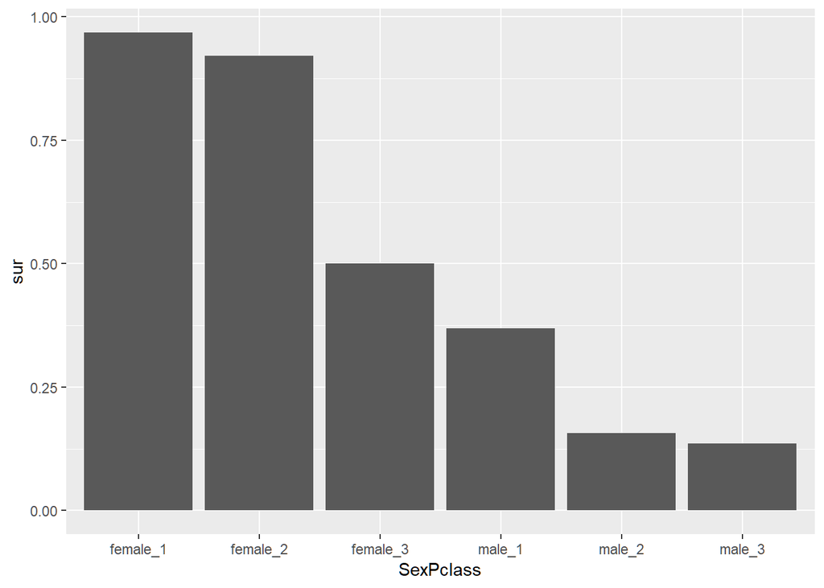

```r
# Bar chart for the surival rate
titanic %>%
  group_by(Sex,Pclass) %>%
  summarise(sur=mean(Survived)) %>%
  ungroup() %>%
  mutate(SexPclass=paste0(Sex,"_",Pclass)) %>%
  ggplot(aes(SexPclass,sur)) +
  geom_bar(stat="identity")
```

# 4 Others

## 4.1 Correlation

Find Spearman Rank’s correlations among Survived, Pclass, Age, SibSp, Parch, Fare. Hint: Use `cor(use="complete.obs", method = "spearman")`.

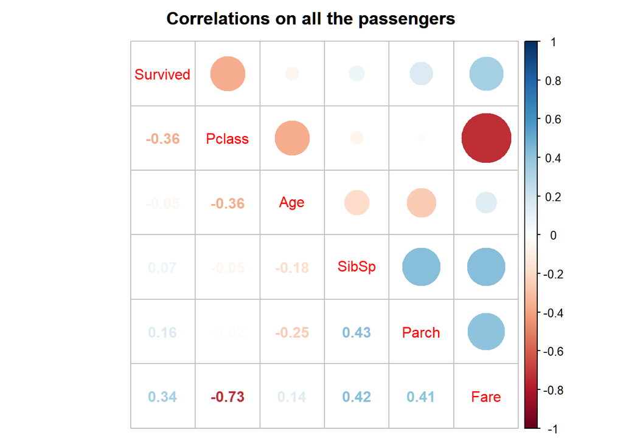

```r
library(corrplot)
# Step 1: Use select to keep the columns: Survived, Pclass, Age, SibSp, Parch, Fare
# Correlations on all the passengers
titanic %>%
  select(Survived,Pclass,Age, SibSp, Parch, Fare) %>%
  cor(use="complete.obs", method = "spearman") %>%
  corrplot.mixed(main="Correlations on all the passengers",
                 mar = c(0, 0, 2, 0))
```

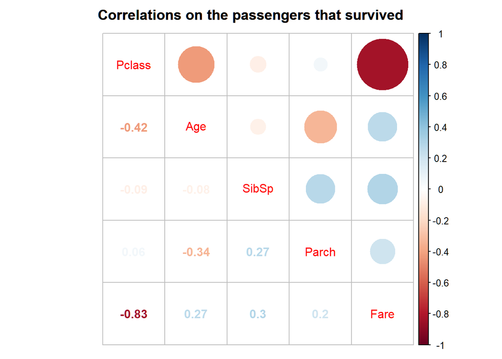

```r
# Step 1: Use filter to keep observations with Survivied==1
# Step 2: Use select to keep the columns: Pclass, Age, SibSp, Parch, Fare
# Correlations on the passengers that survived
titanic %>%
  filter(Survived==1) %>%
  select(Pclass, Age, SibSp, Parch, Fare) %>%
  cor(use="complete.obs", method = "spearman") %>%
  corrplot.mixed(main="Correlations on the passengers that survived",
                 mar = c(0, 0, 2, 0))
```

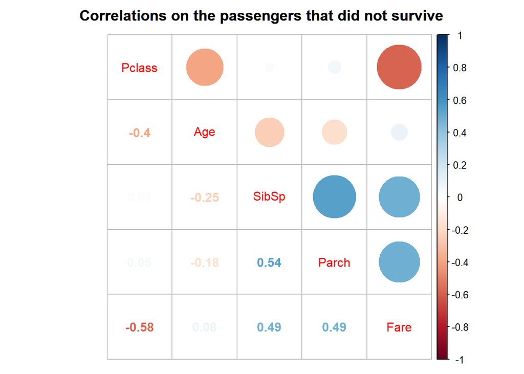

```r
# Step 1: Use filter to keep observations with Survivied==0
# Step 2: Use select to keep the columns: Pclass, Age, SibSp, Parch, Fare
# Correlations on the passengers that did not survive
titanic %>%
  filter(Survived==0) %>%
  select(Pclass, Age, SibSp, Parch, Fare) %>%
  cor(use="complete.obs", method = "spearman") %>%
  corrplot.mixed(main="Correlations on the passengers that did not survive",
                 mar = c(0, 0, 2, 0))
```

## 4.2 Pairwise plot

Create a pairwise plot for variables including SurvivedLabel, Pclass, Sex, Age, SibSp, Parch, Fare, Embarked.

```r
library(GGally)
```

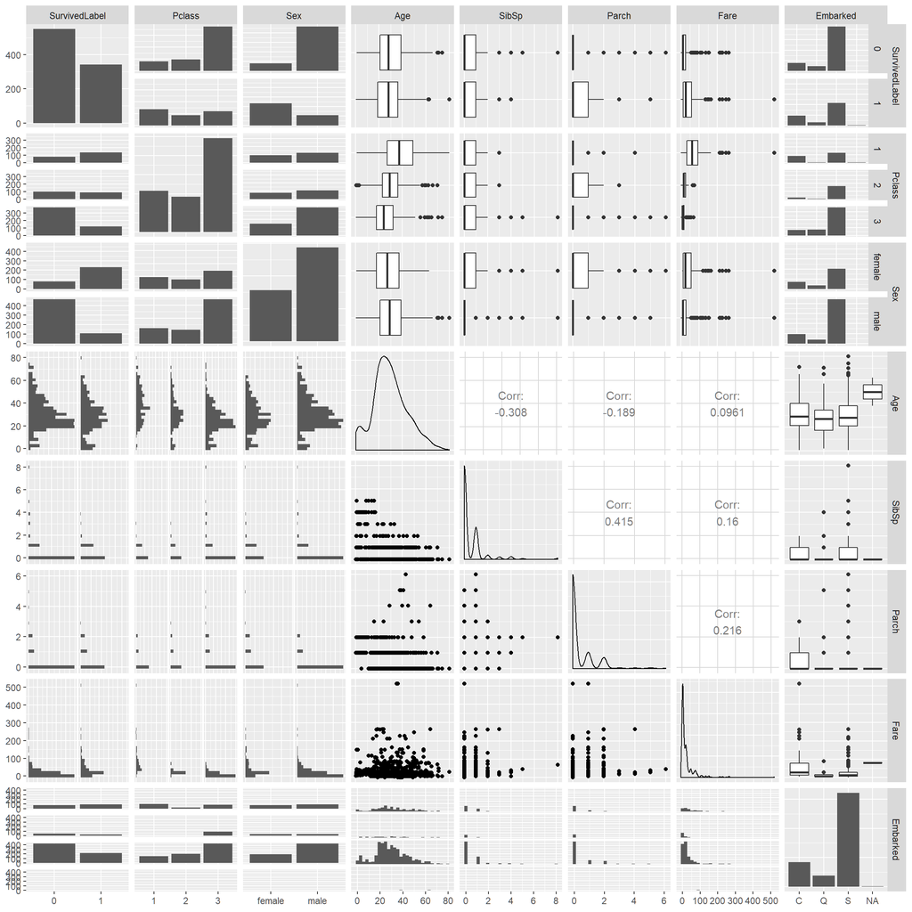

```r
# Step 1: Convert Pclass to a factor
# Step 2: Use select to keep the above mentioned columns
# Step 3: do ggpairs()

titanic %>%
  mutate(Pclass=factor(Pclass)) %>%
  select(SurvivedLabel, Pclass, Sex, Age,
         SibSp, Parch, Fare, Embarked) %>%
  ggpairs()
```

# 5 Feature Engineering on the titanicing Set

What variable can we add?

## 5.1 Discretize Age

Use the function `cut`.

```r
# create age_cut by cutting Age into c("children","adult","senior")
summary(titanic$Age)
```

```
##    Min. 1st Qu.  Median    Mean 3rd Qu.    Max.    NA's
##    0.42   20.12   28.00   29.70   38.00   80.00     177
```

```r
titanic <- titanic %>%
  mutate(age_bin=cut(Age, breaks = c(0,18,60,80),
                     labels=c("children","adult","senior"),
                     include.lowest = TRUE)) %>%
  mutate(age_bin=addNA(age_bin))
titanic %>% select(Age,age_bin) %>% print(n=2)
```

```
## # A tibble: 891 x 2
##     Age age_bin
##   <dbl> <fct>
## 1    22 adult
## 2    38 adult
## # ... with 889 more rows
```

```r
# Categories with NA (not available, i.e., missing values) added
levels(titanic$age_bin)
```

```
## [1] "children" "adult"    "senior"   NA
```

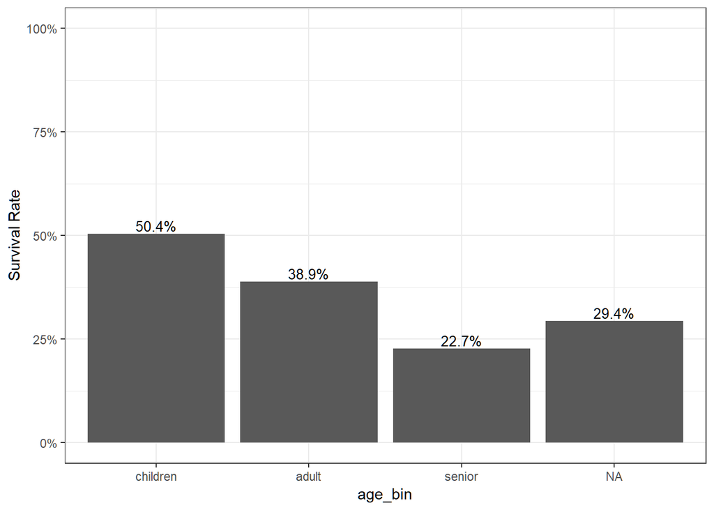

```r
# Barplot of survival rate for each age_bin
titanic %>%
  group_by(age_bin) %>%
  summarize(sur=mean(Survived)) %>%
  ggplot(aes(x=age_bin,y=sur))+
  geom_bar(stat="identity")+
  geom_text(aes(label=scales::percent(sur,
                                      accuracy=0.1,
                                      suffix="%") ),
            size=3.5,vjust=-0.25,
            position = position_dodge(width = 0.9))+
  scale_y_continuous(labels = scales::percent, limits = c(0,1))+
  labs(y="Survival Rate")+
  theme_bw()
```

## 5.2 Discretize Fare

Use the function `cut`.

```r
# create fare_cut by cutting Fare into c("low","medium","high")
# using the first quantile and the third quantile
summary(titanic$Fare)
```

```
##    Min. 1st Qu.  Median    Mean 3rd Qu.    Max.
##    0.00    7.91   14.45   32.20   31.00  512.33
```

```r
titanic <- titanic %>%
  mutate(fare_bin=cut(Fare, breaks = c(0,8,31,550),
                     labels=c("low","medium","high"),
                     include.lowest = TRUE))

titanic %>% select(Fare,fare_bin) %>% print(n=5)
```

```
## # A tibble: 891 x 2
##    Fare fare_bin
##   <dbl> <fct>
## 1  7.25 low
## 2 71.3  high
## 3  7.92 low
## 4 53.1  high
## 5  8.05 medium
## # ... with 886 more rows
```

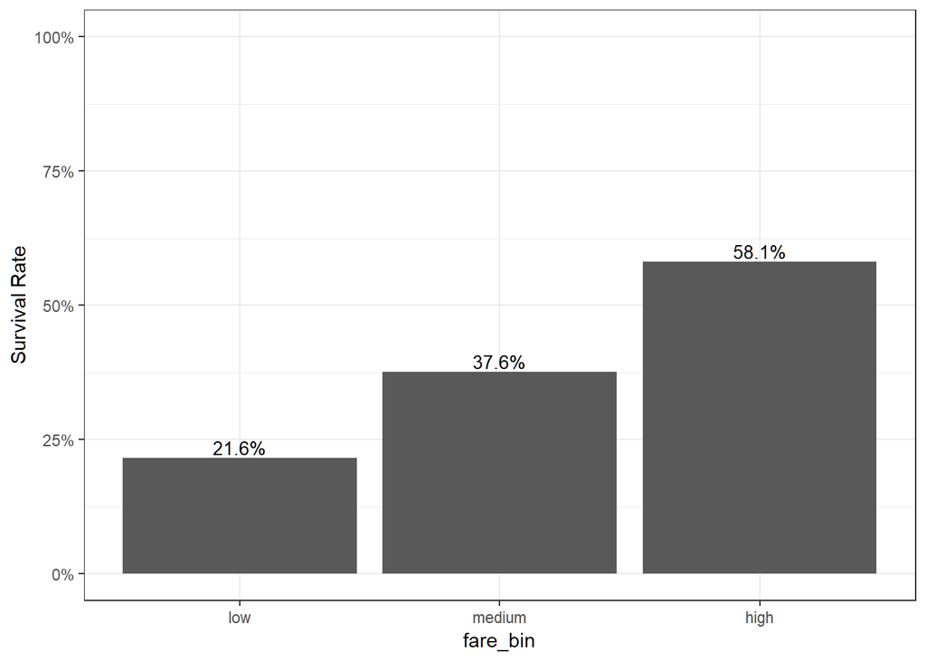

```r
# Barplot of survival rate for each fare_bin
titanic %>%
  group_by(fare_bin) %>%
  summarize(sur=mean(Survived)) %>%
  ggplot(aes(x=fare_bin,y=sur))+
  geom_bar(stat="identity")+
  geom_text(aes(label=scales::percent(sur,
                                      accuracy=0.1,
                                      suffix="%") ),
            size=3.5,vjust=-0.25,
            position = position_dodge(width = 0.9))+
  scale_y_continuous(labels = scales::percent, limits = c(0,1))+
  labs(y="Survival Rate")+
  theme_bw()
```

## 5.3 Family size

Family size = SibSp + Parch

```r
# Add the variable FamilySize
titanic <- titanic %>%
  mutate(FamilySize=SibSp + Parch)


# Use summarise and n() to count each FamilySize
# as well as mean() to compute the survival rate
# Step 1: group_by
# Step 2: summarise
titanic %>%
  group_by(FamilySize) %>%
  summarise(sur=mean(Survived),
            count=n())
```

```
## # A tibble: 9 x 3
##   FamilySize   sur count
##        <int> <dbl> <int>
## 1          0 0.304   537
## 2          1 0.553   161
## 3          2 0.578   102
## 4          3 0.724    29
## 5          4 0.2      15
## 6          5 0.136    22
## 7          6 0.333    12
## 8          7 0         6
## 9         10 0         7
```

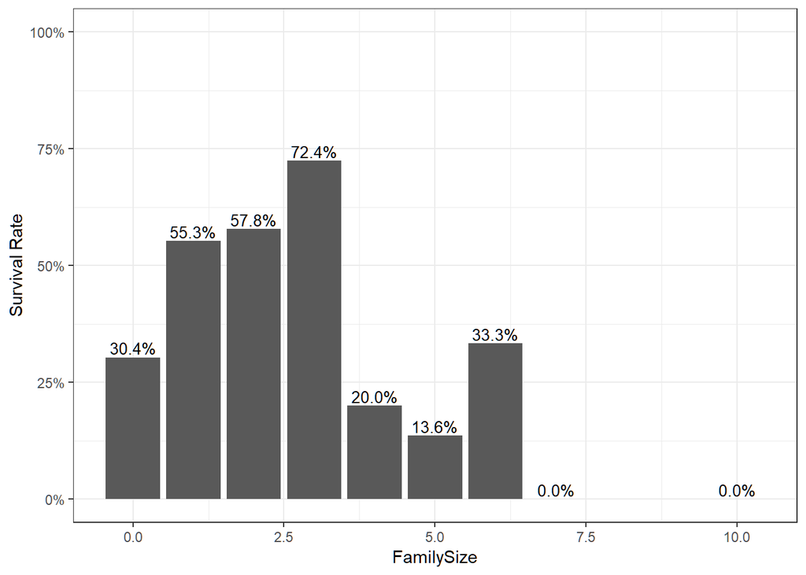

```r
# Bar chart for the surival rate for each FamilySize
titanic %>%
  group_by(FamilySize) %>%
  summarise(sur=mean(Survived)) %>%
  ggplot(aes(FamilySize,sur)) +
  geom_bar(stat="identity")+
  geom_text(aes(label=scales::percent(sur,
                                      accuracy=0.1,
                                      suffix="%") ),
            size=3.5,vjust=-0.25,
            position = position_dodge(width = 0.9))+
  scale_y_continuous(labels = scales::percent, limits = c(0,1))+
  labs(y="Survival Rate")+
  theme_bw()
```

## 5.4 Single

According to the family size, we can create a variable `single` which is TRUE if `FamilySize<1`.

```r
# Add the variable Single
titanic <- titanic %>%
  mutate(Single= FamilySize<1)

# Use summarise and n() to count by Single
# as well as mean() to compute the survival rate
# Step 1: group_by
# Step 2: summarise
titanic %>%
  group_by(Single) %>%
  summarise(sur=mean(Survived),
            count=n())
```

```
## # A tibble: 2 x 3
##   Single   sur count
##   <lgl>  <dbl> <int>
## 1 FALSE  0.506   354
## 2 TRUE   0.304   537
```

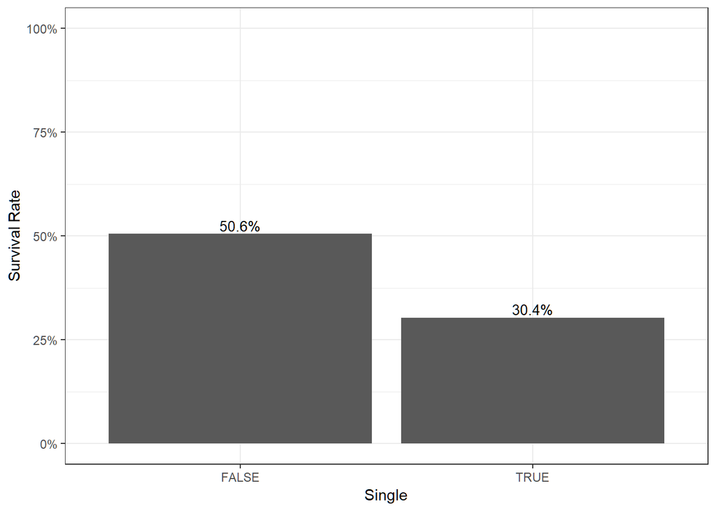

```r
# Bar chart for the surival rate by Single
titanic %>%
  group_by(Single) %>%
  summarise(sur=mean(Survived)) %>%
  ggplot(aes(Single,sur)) +
  geom_bar(stat="identity")+
  geom_text(aes(label=scales::percent(sur,
                                      accuracy=0.1,
                                      suffix="%") ),
            size=3.5,vjust=-0.25,
            position = position_dodge(width = 0.9))+
  scale_y_continuous(labels = scales::percent, limits = c(0,1))+
  labs(y="Survival Rate")+
  theme_bw()
```

## 5.5 Tickets

There are 891 obervations in this data set but only 681 unique tikets. So there were passengers with the same ticket. This infomation might help predict the survival rate.

Since there are so many levels for this categorical variable, we may use the count encoding for `Ticket`.

```r
# Create a new variable: shareTicket
# Step 1: Group by Ticket
# Step 2: summarise and n() to count the number of passengers for each ticket
# Step 3: Use mutate to create a varaible shareTicket which is TRUE if the ticket was shared by more than one person
# Step 4: Join to the original data set
titanic <- titanic %>%
  group_by(Ticket) %>%
  summarise(shareTicket=n()) %>%
  mutate(shareTicket=shareTicket>1) %>%
  right_join(titanic, by ="Ticket")


# Use summarise and n() to count each shareTicket
# as well as mean() to compute the survival rate
# Step 1: group_by
# Step 2: summarise
titanic %>%
  group_by(shareTicket) %>%
  summarise(sur=mean(Survived),
            count=n())
```

```
## # A tibble: 2 x 3
##   shareTicket   sur count
##   <lgl>       <dbl> <int>
## 1 FALSE       0.298   547
## 2 TRUE        0.520   344
```

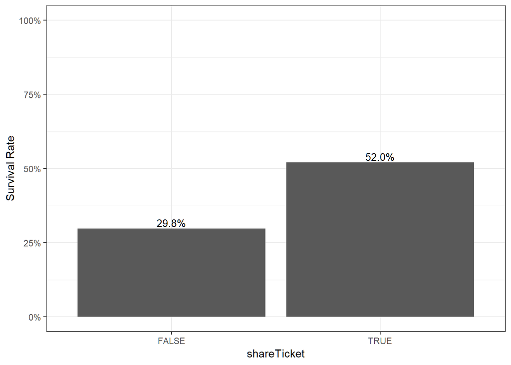

```r
# Bar chart for the surival rate for each shareTicket
titanic %>%
  group_by(shareTicket) %>%
  summarise(sur=mean(Survived)) %>%
  ggplot(aes(shareTicket,sur)) +
  geom_bar(stat="identity")+
  geom_text(aes(label=scales::percent(sur,
                                      accuracy=0.1,
                                      suffix="%") ),
            size=3.5,vjust=-0.25,
            position = position_dodge(width = 0.9))+
  scale_y_continuous(labels = scales::percent, limits = c(0,1))+
  labs(y="Survival Rate")+
  theme_bw()
```

## 5.6 Target encoding

Target encoding for Pclass is not useful because the Pclass has too few levels and one can apply the one-hot encoding without any difficulty.

In practice, we do not have the (Survived) labels in the testing set. So we will use the what are learnt in the training set for the categories appear in testing set.

```r
# Create a new variable: surPclass
# Step 1: Group by Pclass
# Step 2: summarise and mean to find the survival ratio for each Pclass
# Step 3: Join to the original data set
# Step 4: Add random noises rnorm(nrow(titanic),sd=0.01) to the
titanic %>%
  group_by(Pclass) %>%
  summarise(surPclass=mean(Survived)) %>%
  right_join(titanic, by ="Pclass") %>%
  select(Pclass,surPclass) %>%
  mutate(surPclass=surPclass+rnorm(nrow(titanic),sd=0.01))        # add noise
```

```
## # A tibble: 891 x 2
##    Pclass surPclass
##     <int>     <dbl>
##  1      3     0.239
##  2      1     0.631
##  3      3     0.248
##  4      1     0.637
##  5      3     0.236
##  6      3     0.229
##  7      1     0.613
##  8      3     0.237
##  9      3     0.246
## 10      2     0.465
## # ... with 881 more rows
```

# 6 Predict Survival Rate

We use the logistic regression to model the probability (rate) of survival.

Data are split into the training set and the testing set.

```r
# Convert categories to factors for variables:  Pclass, Sex, Single, Embarked
# filter out missing values of Embarked
# select columns: SurvivedLabel, Pclass, Sex, age_bin, fare_bin, Embarked
# Assign to a new R object, titanic2
titanic2 <- titanic %>%
  mutate(Pclass=factor(Pclass), Sex=factor(Sex),
         Single=factor(Single),Embarked=factor(Embarked)) %>%
  filter(!is.na(Embarked)) %>%
  select(SurvivedLabel, Pclass, Sex, Single,age_bin, fare_bin, Embarked)

titanic2
```

```
## # A tibble: 889 x 7
##    SurvivedLabel Pclass Sex    Single age_bin  fare_bin Embarked
##    <fct>         <fct>  <fct>  <fct>  <fct>    <fct>    <fct>
##  1 0             3      male   FALSE  adult    low      S
##  2 1             1      female FALSE  adult    high     C
##  3 1             3      female TRUE   adult    low      S
##  4 1             1      female FALSE  adult    high     S
##  5 0             3      male   TRUE   adult    medium   S
##  6 0             3      male   TRUE   <NA>     medium   Q
##  7 0             1      male   TRUE   adult    high     S
##  8 0             3      male   FALSE  children medium   S
##  9 1             3      female FALSE  adult    medium   S
## 10 1             2      female FALSE  children medium   C
## # ... with 879 more rows
```

```r
# Randomly split into train and test
set.seed(111)
train_idx <- sample(1:nrow(titanic2), size = 500, replace = FALSE)
train <- titanic2[train_idx,]
test <- titanic2[-train_idx,]

# Train logisitc regression model
fit1 <- glm(SurvivedLabel~Pclass+Sex+Single+age_bin+fare_bin+Embarked,
            data=train, family = binomial)

# Estimated coefficients and significances
summary(fit1)
```

```
##
## Call:
## glm(formula = SurvivedLabel ~ Pclass + Sex + Single + age_bin +
##     fare_bin + Embarked, family = binomial, data = train)
##
## Deviance Residuals:
##     Min       1Q   Median       3Q      Max
## -2.4928  -0.6540  -0.3768   0.6155   2.7260
##
## Coefficients:
##                Estimate Std. Error z value Pr(>|z|)
## (Intercept)      4.5157     0.7689   5.873 4.28e-09 ***
## Pclass2         -1.2712     0.4162  -3.054 0.002259 **
## Pclass3         -2.4474     0.4239  -5.774 7.75e-09 ***
## Sexmale         -2.5239     0.2631  -9.592  < 2e-16 ***
## SingleTRUE      -0.2873     0.2935  -0.979 0.327586
## age_binadult    -0.9151     0.3495  -2.618 0.008841 **
## age_binsenior   -3.2875     1.2075  -2.723 0.006479 **
## age_binNA       -1.4936     0.4533  -3.295 0.000984 ***
## fare_binmedium  -0.4861     0.3778  -1.287 0.198169
## fare_binhigh    -0.9888     0.5295  -1.867 0.061850 .
## EmbarkedQ        0.2941     0.5331   0.552 0.581241
## EmbarkedS       -0.4657     0.3040  -1.532 0.125529
## ---
## Signif. codes:  0 '***' 0.001 '**' 0.01 '*' 0.05 '.' 0.1 ' ' 1
##
## (Dispersion parameter for binomial family taken to be 1)
##
##     Null deviance: 670.50  on 499  degrees of freedom
## Residual deviance: 451.27  on 488  degrees of freedom
## AIC: 475.27
##
## Number of Fisher Scoring iterations: 5
```

```r
# Perform backward stepwise model selection according to the AIC (smaller is better)
fit2 <- step(fit1)
```

```
## Start:  AIC=475.27
## SurvivedLabel ~ Pclass + Sex + Single + age_bin + fare_bin +
##     Embarked
##
##            Df Deviance    AIC
## - Single    1   452.23 474.23
## - fare_bin  2   454.85 474.85
## <none>          451.27 475.27
## - Embarked  2   455.48 475.48
## - age_bin   3   469.44 487.44
## - Pclass    2   488.62 508.62
## - Sex       1   563.78 585.78
##
## Step:  AIC=474.23
## SurvivedLabel ~ Pclass + Sex + age_bin + fare_bin + Embarked
##
##            Df Deviance    AIC
## - fare_bin  2   454.86 472.86
## <none>          452.23 474.23
## - Embarked  2   456.48 474.48
## - age_bin   3   472.61 488.61
## - Pclass    2   488.87 506.87
## - Sex       1   572.85 592.85
##
## Step:  AIC=472.86
## SurvivedLabel ~ Pclass + Sex + age_bin + Embarked
##
##            Df Deviance    AIC
## <none>          454.86 472.86
## - Embarked  2   459.98 473.98
## - age_bin   3   473.51 485.51
## - Pclass    2   497.43 511.43
## - Sex       1   573.88 589.88
```

```r
summary(fit2) #Single, fare_bin is removed
```

```
##
## Call:
## glm(formula = SurvivedLabel ~ Pclass + Sex + age_bin + Embarked,
##     family = binomial, data = train)
##
## Deviance Residuals:
##     Min       1Q   Median       3Q      Max
## -2.4510  -0.6891  -0.4373   0.6375   2.4170
##
## Coefficients:
##               Estimate Std. Error z value Pr(>|z|)
## (Intercept)     3.4197     0.4582   7.464 8.42e-14 ***
## Pclass2        -0.9470     0.3497  -2.708 0.006762 **
## Pclass3        -1.9294     0.3118  -6.187 6.12e-10 ***
## Sexmale        -2.4639     0.2469  -9.980  < 2e-16 ***
## age_binadult   -0.8586     0.3275  -2.622 0.008737 **
## age_binsenior  -3.2461     1.1941  -2.718 0.006559 **
## age_binNA      -1.4251     0.4260  -3.345 0.000823 ***
## EmbarkedQ       0.4133     0.5240   0.789 0.430276
## EmbarkedS      -0.4668     0.3046  -1.532 0.125405
## ---
## Signif. codes:  0 '***' 0.001 '**' 0.01 '*' 0.05 '.' 0.1 ' ' 1
##
## (Dispersion parameter for binomial family taken to be 1)
##
##     Null deviance: 670.50  on 499  degrees of freedom
## Residual deviance: 454.86  on 491  degrees of freedom
## AIC: 472.86
##
## Number of Fisher Scoring iterations: 5
```

```r
# Predict the survival rates for passengers in the testing set
pred_fit2 <- predict(fit2, newdata = test,
                     type = "response", se.fit = TRUE)
# Format the predictions
format_pred <- tibble(predSurv=ifelse(pred_fit2$fit>0.5,1,0),
                      survRate=pred_fit2$fit,
                      se=pred_fit2$se.fit)
format_pred
```

```
## # A tibble: 389 x 3
##    predSurv survRate     se
##       <dbl>    <dbl>  <dbl>
##  1        1   0.928  0.0234
##  2        0   0.0912 0.0207
##  3        0   0.121  0.0469
##  4        1   0.890  0.0311
##  5        0   0.0912 0.0207
##  6        0   0.0912 0.0207
##  7        1   0.736  0.0646
##  8        1   0.759  0.0543
##  9        0   0.363  0.125
## 10        1   0.516  0.107
## # ... with 379 more rows
```

```r
# Accuracy
mean(format_pred$predSurv == test$SurvivedLabel)
```

```
## [1] 0.7994859
```

```r
# Confusion table
table(Prediction=format_pred$predSurv, Truth=test$SurvivedLabel)
```

```
##           Truth
## Prediction   0   1
##          0 210  42
##          1  36 101
```

```r
#------------- Forecasts for all combinations ------------------#
newtest <- expand.grid( Pclass = c("1","2","3"),
                        Sex = c("male","female"),
                        age_bin = c("children","adult","senior",NA),
                        Embarked = c("C","Q","S"))
pred_newtest <- predict(fit2, newdata = newtest,
                     type = "response")

# Format
as_tibble(newtest) %>%
  bind_cols(tibble(survRate=pred_newtest)) %>%
  arrange(desc(survRate)) %>%
  print(n=100)
```

```
## # A tibble: 72 x 5
##    Pclass Sex    age_bin  Embarked survRate
##    <fct>  <fct>  <fct>    <fct>       <dbl>
##  1 1      female children Q         0.979
##  2 1      female children C         0.968
##  3 1      female adult    Q         0.951
##  4 1      female children S         0.950
##  5 2      female children Q         0.947
##  6 1      female adult    C         0.928
##  7 2      female children C         0.922
##  8 1      female <NA>     Q         0.917
##  9 1      female adult    S         0.890
## 10 2      female adult    Q         0.884
## 11 2      female children S         0.881
## 12 1      female <NA>     C         0.880
```

[output cut: 60 more lines]